# Regresja i analiza wariancji - Laboratorium 7

Dwuczynnikowa analiza wariancji

Adrian Kowalski

Politechnika Krakowska

# Dwuczynnikowa analiza wariancji

Do tej pory wykonywaliśmy testy za pomocą jednoczynnikowej analizy wariancji, która pozwalała nam porównywać grupy na podstawie jednej kategoryzacji. Na dzisiejszych zajęciach poznamy rozszerzenie tej metody, dwuczynnikową analizę wariancji (Two-way ANOVA). Pozwala nam ona badać zależność średniej między zbiorami pogrupowanymi względem dwóch zmiennych kategoryzjuących oraz badania interakcji między kategoriami. W podstawowym modelu dwuczynnikowej analizy wariancji mamy następujące założenia

- próby wewnątrz grup mają rozkład normalny,
- wszystkie próby wewnątrz grup mają stałą i jednakową wariancję,
- próby są niezależne.

Tym razem będziemy chcieli rozbić całkowitą sumę kwadratów z danych na 4 części:
$$SST = SSA + SSB + SSAB + SSE.$$
Oznaczmy przez

- $r$ ilośc kategorii czynnika 1,
- $c$ ilość kategorii czynnika 2,
- $n'$ liczność danej grupy,
- $n$ liczność całej próby,
- $x_ijk$ to $k$-ta obserwacja z poziomu $i$ czynnika 1, poziomu $j$ czynnika 2.

Wtedy wprowadzamy

- $SST = \sum_{i=1}^r \sum_{j=1}^c \sum_{k=1}^{n'} (x_{ijk} - \overline{x})^2$ jest całkowitą sumą kwadratów w danych,
- $SSA = cn'\sum_{i=1}^r (\overline{x}_i - \overline{x})^2$ jest sumą kwadratów w obserwacjach względem pierwszego czynnika,
- $SSB = rn'\sum_{j=1}^c (\overline{x}_j - \overline{x})^2$ jest sumą kwadratów w obserwacjach względem drugiego czynnika,
- $SSAB = n' \sum_{i=1}^r \sum_{j=1}^c (\overline{x}_{ij} - \overline{x}_i - \overline{x}_j + \overline{x})^2$ jest sumą kwadratów wynikającą z interakcji,
- $SSE = \sum_{i=1}^r \sum_{j=1}^c \sum_{k=1}^{n'} (x_{ijk} - \overline{x}_{ij})^2$ to suma kwadratów reszt.

Do wyliczenia statystyki $F$ potrzebujemy wartości średnich powyższych błędów, wyliczamy je jako

- $MSA = \frac{SSA}{r-1}$,
- $MSB = \frac{SSB}{c-1}$,
- $MSAB = \frac{SSAB}{(r-1)(c-1)}$,
- $MSE = \frac{SSE}{rc(n'-1)}$.

Wtedy dla czynnika 1 mamy $F = \frac{MSA}{MSE}$, dla czynnika 2 mamy $F = \frac{MSB}{MSE}$ i dla interakcji $F = \frac{MSAB}{MSE}$. W razie odrzucenia którejś z hipotez zerowych możemy przeprowadzić procedurę Tukeya, lub testy t z poprawką Bonferoniego do wnioskowania post-hoc.

W $R$ do dwukierunkowej analizy wariancji nadal służy funkcja $anova()$. Wprowadźmy dane “Diet” dotyczące wagi osób, które testowały różne diety.

```r
library(tidyverse)
diet <- readr::read_csv('diet.csv')
head(diet)
```

| Person | gender | Age | Height | pre.weight | Diet | weight6weeks |
| --- | --- | --- | --- | --- | --- | --- |
| 15 | 1 | 39 | 168 | 71 | 1 | 71.6 |
| 16 | 1 | 31 | 158 | 72 | 1 | 70.9 |
| 17 | 1 | 40 | 173 | 74 | 1 | 69.5 |
| 18 | 1 | 50 | 160 | 78 | 1 | 73.9 |
| 19 | 1 | 43 | 162 | 80 | 1 | 71.0 |
| 20 | 1 | 25 | 165 | 80 | 1 | 77.6 |

Zauważmy, że w czystych danych mamy jedynie wagę przed i wagę po eksperymencie. Musimy jeszcze wytworzyć zmienną dotyczącą zmiany w wadze po eksperymencie.

```r
diet <- diet %>% dplyr::mutate(weightLoss = weight6weeks - pre.weight) %>% dplyr::mutate(gender = as.factor(gender)) %>% dplyr::mutate(Diet = as.factor(Diet))
head(diet)
```

| Person | gender | Age | Height | pre.weight | Diet | weight6weeks | weightLoss |
| --- | --- | --- | --- | --- | --- | --- | --- |
| 15 | 1 | 39 | 168 | 71 | 1 | 71.6 | 0.6 |
| 16 | 1 | 31 | 158 | 72 | 1 | 70.9 | -1.1 |
| 17 | 1 | 40 | 173 | 74 | 1 | 69.5 | -4.5 |
| 18 | 1 | 50 | 160 | 78 | 1 | 73.9 | -4.1 |
| 19 | 1 | 43 | 162 | 80 | 1 | 71.0 | -9.0 |
| 20 | 1 | 25 | 165 | 80 | 1 | 77.6 | -2.4 |

W danych mamy dwie zmienne, które możemy wykorzystać jako czynniki - płeć i rodzaj diety. Zastanówmy się na chwilę, czy nie moglibyśmy jeszcze skorzystać ze zmiennej wiek jako czynnik. W tym celu przeprowadzimy proces tzw. koszykowania (bucketing).

```r
table(diet$Age)
```

```
16 20 21 22 25 26 28 29 30 31 32 33 35 36 37 38 39 40 41 42 43 44 45 46 47 48 49 50 51 52 54 55 56 58 60
 1  2  1  2  1  1  3  2  1  5  1  2  4  2  8  1  3  5  4  1  2  2  3  1  1  3  1  4  4  1  2  1  1  1  1
```

```r
quantile(diet$Age)
```

```
   0%   25%   50%   75%  100%
16.00 32.25 39.00 46.75 60.00
```

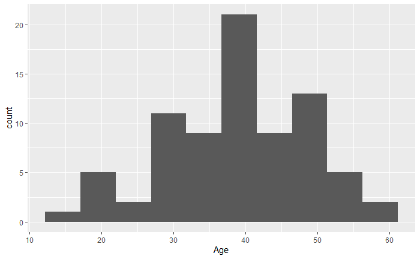

```r
ggplot(diet, aes(x=Age)) + geom_histogram(bins = 10)
```

```r
diet <- diet %>% dplyr::mutate(ageGrp = cut(Age, breaks=c(15,35,45,60)))
head(diet)
```

| Person | gender | Age | Height | pre.weight | Diet | weight6weeks | weightLoss | ageGrp |
| --- | --- | --- | --- | --- | --- | --- | --- | --- |
| 15 | 1 | 39 | 168 | 71 | 1 | 71.6 | 0.6 | (35,45] |
| 16 | 1 | 31 | 158 | 72 | 1 | 70.9 | -1.1 | (15,35] |
| 17 | 1 | 40 | 173 | 74 | 1 | 69.5 | -4.5 | (35,45] |
| 18 | 1 | 50 | 160 | 78 | 1 | 73.9 | -4.1 | (45,60] |
| 19 | 1 | 43 | 162 | 80 | 1 | 71.0 | -9.0 | (35,45] |
| 20 | 1 | 25 | 165 | 80 | 1 | 77.6 | -2.4 | (15,35] |

```r
table(diet$ageGrp)
```

[output not shown]

Teraz ze zmiennej liczbowej Age stworzyliśmy zmienną kategorialną ageGrp i możemy ją wykorzystać w analizie wariancji. Przejdźmy do wykresów, które pomogą w interpretacji wizualnej danych,

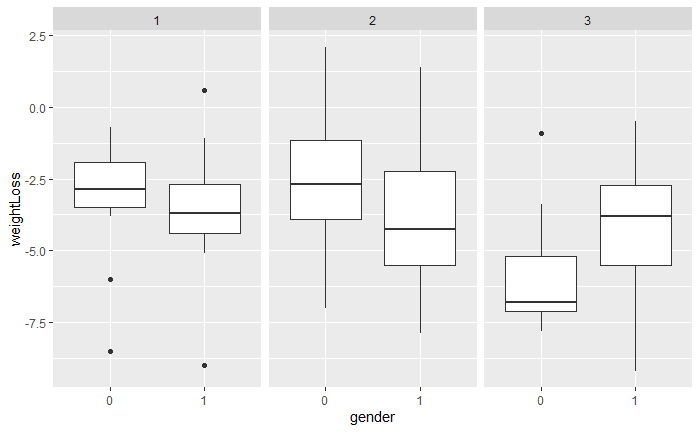

```r
ggplot(diet, aes(x=gender, y=weightLoss)) + geom_boxplot() + facet_wrap(~Diet)
```

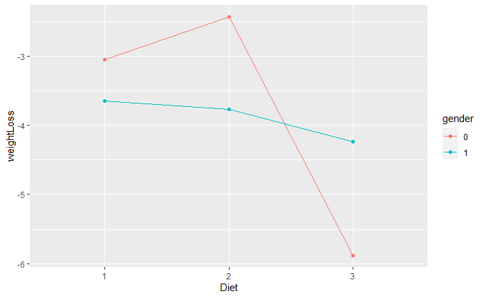

```r
ggplot(diet, aes(x=Diet, y=weightLoss, color=gender, group=gender)) + stat_summary(fun=mean, geom = 'point') + stat_summary(fun=mean, geom='line')
```

```r
summary(aov(weightLoss ~ Diet*ageGrp*gender, data=diet))
```

```
                   Df Sum Sq Mean Sq F value  Pr(>F)
Diet                2   71.1   35.55   5.958 0.00436 **
ageGrp              2    0.5    0.27   0.045 0.95567
gender              1    0.0    0.03   0.006 0.93972
Diet:ageGrp         4    2.3    0.58   0.098 0.98273
Diet:gender         2   33.5   16.74   2.806 0.06839 .
ageGrp:gender       2    6.4    3.19   0.535 0.58869
Diet:ageGrp:gender  4   29.4    7.36   1.233 0.30650
Residuals          60  358.0    5.97
---
Signif. codes:  0 ‘***’ 0.001 ‘**’ 0.01 ‘*’ 0.05 ‘.’ 0.1 ‘ ’ 1
```

#Cwiczenie

W pliku ‘halo1.dat’ znajdują się dane pochodzące z badania na temat efektu aureoli. Mamy dwa czynniki - “jakość eseju” i “atrakcyjność autora” i jedną zmienną objaśnianą - “ocenę”. Eseje dzielimy na “dobre - 1” i “złe - 2”, atrakcyjność dzielimy na “1 - wysoką, 2 - grupa kontrolna, 3 - niewysoką”. Przy pomocy analizy wariancji stwierdzić czy czynniki mają wypływ na wynik. (Dane pochodzą z [źródła](https://users.stat.ufl.edu/~winner/datasets.html), tam też można znaleźć ich opis pod nazwą “Beauty and Judgement - Halo Effect” jak i odnośniki do oryginalnego badania).

```r
halo <- readr::read_table('halo1.dat', col_names = c('essay_quality', 'attractiveness', 'score'))
halo <- halo %>% dplyr::mutate(essay_quality = as.factor(essay_quality)) %>% dplyr::mutate(attractiveness = as.factor(essay_quality))
head(halo)
```